# Deep Learning with Convnets: Computer Vision

## Step 7: Regularizing the model

To further reduce the amount of overfitting, we can first try the following two regularization techniques in conjunction:

- Dropout
- L2 regularization

Dropout essentially introduces noise in the outputs tensors of the convnets' layers, making it harder for the model to memorise patterns that are not significant. L2 regularization is a form of weight decay that helps to prevent overfitting via a reduction in the values of a layer's weight coefficients. (DLWP)

Let's see this in action by training a new model using these techniques. Apart from regularization, the configuration will be the same.

```python
from tensorflow.keras import regularizers

model = create_model(4, dropout=0.5, regularizer=regularizers.l2(0.002))
callbacks, history = train_model(model, 20)
```

The following output was produced for the first six epochs:

```
Epoch 1/20
469/469 [==============================] - 160s 337ms/step - loss: 0.7273 - accuracy: 0.4994 - val_loss: 0.6936 - val_accuracy: 0.5000
Epoch 2/20
469/469 [==============================] - 162s 346ms/step - loss: 0.6937 - accuracy: 0.4931 - val_loss: 0.6936 - val_accuracy: 0.5000
Epoch 3/20
469/469 [==============================] - 166s 355ms/step - loss: 0.6936 - accuracy: 0.4943 - val_loss: 0.6936 - val_accuracy: 0.5000
Epoch 4/20
469/469 [==============================] - 159s 339ms/step - loss: 0.6936 - accuracy: 0.4969 - val_loss: 0.6936 - val_accuracy: 0.5000
Epoch 5/20
469/469 [==============================] - 156s 332ms/step - loss: 0.6936 - accuracy: 0.4957 - val_loss: 0.6936 - val_accuracy: 0.5000
Epoch 6/20
469/469 [==============================] - 155s 331ms/step - loss: 0.6936 - accuracy: 0.4956 - val_loss: 0.6936 - val_accuracy: 0.5000
```

Clearly there is something wrong with this, as the validation loss and accuracy are hanging at 69.36% and 50% respectively. We could try tinkering with the L2 regularization constant, but since the network is quite large, L2 regularization may be unnecessary in the first place since it is mostly used with smaller models according to DLWP. Let's instead try again using only a dropout regularization strategy.

```python
model = create_model(4, dropout=0.5)
callbacks, history = train_model(model, 20)
```

# Results

The results of regularizing the model can be seen as follows.

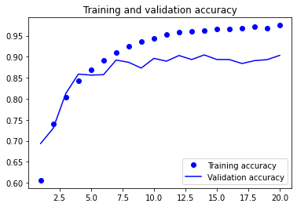

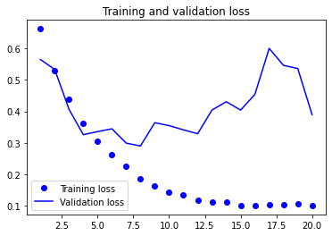

```python
plot_results(history)
```

We see that the dropout has worked to slightly reduce overfitting and that the optimal number of epochs is now 8.

```python
get_optimal_epoch(history)
```

```
8
```

Now to evaluate on the test dataset using the model trained with the optimal number of epochs.

```python
test_model("convnet_from_scratch.keras", test_dataset)
```

```
Test accuracy: 0.886
```

The accuracy of the classifier on unseen data has also increased to 88.6%.

One reason that the dropout only slightly improved the model may be that the dataset is too large for any type of regularization to have much effect. In order to combat overfitting further, we should try tuning the model using various different hyperparameters such as the optimizer's learning rate and the units per layer.

# Conclusion

We have seen the effectiveness of convnet layers for deep learning tasks related to computer vision. We have furthermore developed a binary classification model for images that beats a common sense baseline by a significant margin of predictive accuracy: 88.6% to 50%. We then observed how dropout regularization can help to reduce overfitting with large complex models, although its effect was limited in this case. Finally, we noted that further work should be done to combat overfitting by tuning the hyperparamters of the model. Doing this effectively should further increase the model's predictive accuracy on unseen data.